# LAB_3

Bartosz Łabiszak, Zakład Ekologii Roślin i Ochrony Środowiska

# Genomika Populacyjna: Wykrywanie Doboru Naturalnego - ocena niedopasowania genetycznego do przyszłego klimatu

## Wstęp

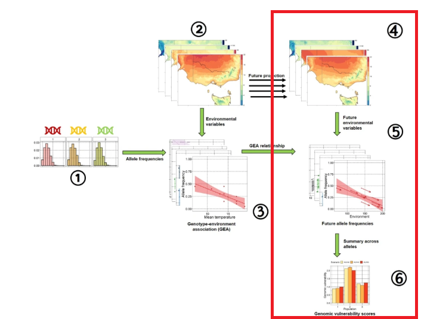

**1. Opis danych do wykonania ćwiczeń**

Na dzisiejszych zajęciach wykorzystamy informacje o SNP związanych z adaptacją do środwiska uzyskaną dzięki metodom **skanów genomowych** i analizy **GEA** do prognozowania ryzyka niedopasowania współczesnego tła genetycznego do przyszłych warunków środowiskowych -**genomic vulnerability** - **kroki (4-6)**.

Dane z którymi Państwo pracują pochodzą z publikacji *Adaptive potential and genomic vulnerability of keystone forest tree species to climate change: a case study in Scots pine* która jest w recenzji w czasopiśmie Evolutionary Applications. Dane pochodzą z sekwencjonowania SNP-chip przy użyciu płytki Axiom-Pine GAP osobników sosny zwyczajnej w gradiencie środowiskowym z Finlandi do Polski.

## SNP outlierowe - rozkład częstości i korelacje

Porównamy rozkład częstości SNP outlierowych w badanym gradiencie środowiskowych i zestawimy go z losowo wybranymi SNP. Sprawdzimy też ich korelację ze zmienną **mean_t.**

```r
# Load necessary libraries
packages <- c( "ggplot2", "adegenet", "poppr", "ggpubr", "rnaturalearth", "rnaturalearthdata", "geodata", "terra", "psych", "adespatial","vegan", "ggvegan", "dplyr", "sf", "AlleleShift", "tidyr", "stringr", "gstat", "RColorBrewer")

#librarises

lapply(packages, require, character.only = TRUE)
```

Zacznijmy od przygotowania danych. Będziemy potrzebowali danych w formacie **genind**, **metadanych** - głównie do kolorowania, **danych środowiskowych** (4 zmienne), **częstości alleli,** oraz listy SNP uznanych za outlierowe przez 3 metody - **PAV** (ang. *potentialy adaptive variants*). Wszystkie te dane są dostępnę w plikach potrzebnych na dziś.

```r
# wczytaj dane zapisane jako pliki RDS

PAV_df <- readRDS(file = "PAV_df")
# sprawdź co zawiera ta ramka?
allele_freqs <- ...
env_df <- ...
genind_pines <- ...
meta_pops <- ...
# zdefiniuj wektor kolory jak ostatnio
kolory <- ...
```

Wykonaj wizualizację częstości alleli dla pojedynczego SNP.

```r
# przytniemy ramkę częstości alleli do naszych SNP outlierowych

PAV_allel_freq <- allele_freqs[, XXX]  # pamiętaj SNP position to kolejność SNP w naszej ramce - użyj to do subsetingu
PAV_allel_freq$region <-  # dodaj kolumnę region
PAV_allel_freq$pop <-  #dodaj kolumnę pop
# upewnij się ile mamy kolumn, ile wierszy, ile SNP i jakie są ich nazwy?
```

Twoja ramka powinna wyglądac tak:

```
##        Kevin_555_1_960_G.T CL1489_1_1_635_T.A comp53210_c0_seq1_185_G.A
## FIN_13           0.1000000          0.7222222                 0.4500000
## FIN_12           0.0000000          0.4000000                 0.8500000
## FIN_4            0.3750000          0.4285714                 0.7142857
## FIN_14           0.0000000          0.5000000                 0.6000000
## FIN_15           0.0000000          0.6111111                 0.8125000
## FIN_10           0.2000000          0.5000000                 0.5000000
## FIN_9            0.7777778          0.5000000                 0.6500000
## FIN_16           0.3750000          0.3888889                 0.7222222
## FIN_17           0.1818182          0.5454545                 0.7272727
## FIN_8            0.1000000          0.5555556                 0.7000000
##        comp53920_c0_seq1_2107_T.A
## FIN_13                  0.6500000
## FIN_12                  0.9500000
## FIN_4                   0.7857143
## FIN_14                  0.7000000
## FIN_15                  0.7777778
## FIN_10                  0.9000000
## FIN_9                   0.8500000
## FIN_16                  0.9444444
## FIN_17                  0.8181818
## FIN_8                   0.8500000
```

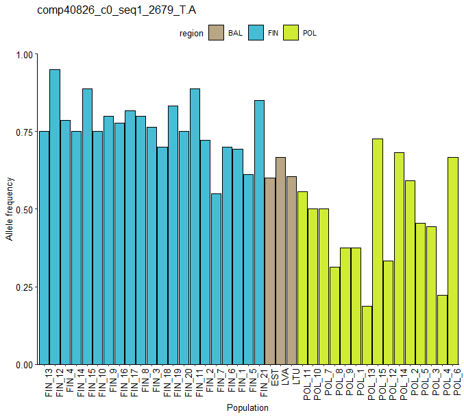

```r
#pojedynczy SNP - wizualizacja

# jako zmienna y użyj częstości dowolnego allelu
# poniżej używamy factor i ustawiamy levels by zachować oryginalną kolejność - z północy na południe

ggplot(data = PAV_allel_freq, aes(x =pop, y = XXX, fill = region))+
  geom_bar(stat = "identity", colour = "black", size = 0.3)+
  scale_y_continuous(limits = c(0,1), expand = c(0,0))+
  #słupki barplotu zaczynają się równo od 0 dzięki powyższej lini
  scale_fill_manual(values = kolory)+
  ylab("Allele frequency")+
  xlab("Population")+
  ggtitle("XXX") # nazwa SNP
  theme_pubr(base_size = 10, x.text.angle = 90)
```

Wykonaj wizualazację rozkładu częstośći wszystkich SNP outlierowych. Użyj dowolnej metody (tak, możesz powtórzyć ten kod 28 razy ;) - Podaj w raporcie kod, którym uzyskałeś ten wykres.

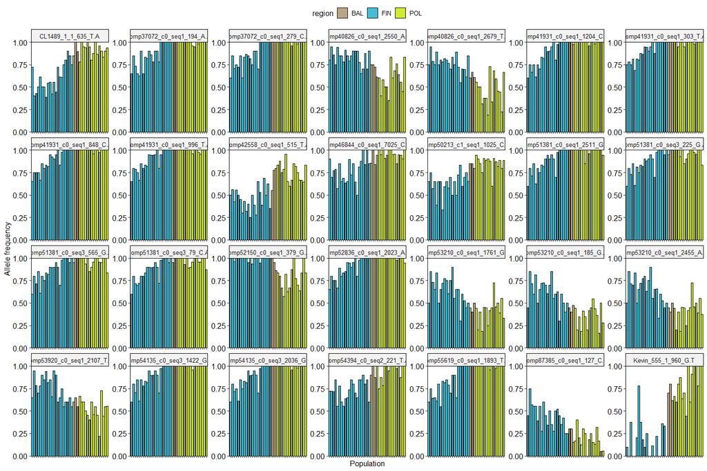

**Zajrzyj - jeśli utknąłeś**

```r
# Nie tym razem ;)

# podejście, którego użyłem to połączenie pivot_longer na ramce częstości alleli
# kolumna pop to factor - więc kolejność pop będzie zachowana

# do rysowania analogiczny kod jak w manualu, z dodanym facet_wrap
```

Teraz porównanym częstości alleli oznaczonych jako potencjalnie adaptacyjnych z częstością losowo wybranych SNP.

```r
# sprawdź wymiary ramki allele freqs

dim(allele_freqs) # ilość SNP to 10597 - 2 dodatkowe kolumny to pop i region - są już factorem

# wybierz 4 losowe SNP - (4 bo jeśli robiłeś to co wyżej na piechotę - nie chcę żebyś robił to 2 raz :)
random_SNPs <- sample(x = XXX, size = XXX)
# tak, możesz wybrać 4 dowolne i zapisać je po prostu jako wektor

rand_allel_freq <- allele_freqs[,c(random_SNPs, 10598:10599)]

# do rysowania częstości alleli użyj analogicznego kodu jak dla SNP outlierowych (PAV)
```

Rozkład częstości 4 losowych SNP

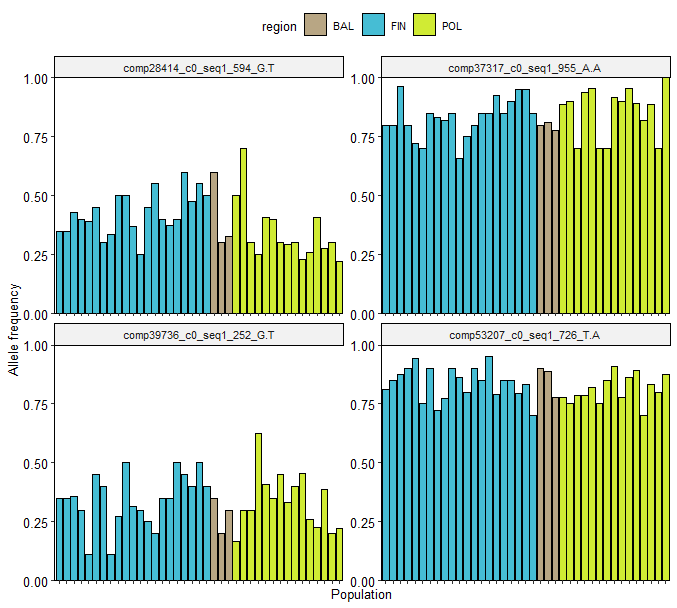

Sprawdźmy korelację SNP z zmienną temperarturową - **mean_t**

```r
# najpierw przygotujmy ramkę danych do wyrysowania korelacji
df_corr <- cbind(PAV_allel_freq, mean_t = env_df$mean_t)

#zmieniamy nazwy SNP na zgodne z ich pozycją - tzn SNP_15 itp
colnames(df_corr)[1:28] <- paste0("SNP_", XXX)
## pamiętaj SNP position jest w ramce PAV

env_df$mean_t
colnames(df_corr)[1:28]

cor_with_temp <- (cor(df_corr$mean_t, df_corr[ , 1:28]))
# poziom korelacji dla kazdego SNP


df_long_corr <- df_corr %>%
  pivot_longer(cols = starts_with("SNP"), names_to = "allele", values_to = "frequency")
df_long_corr$allele <- factor(df_long_corr$allele, levels = colnames(df_corr)[1:28])
all_SNP_plot <- ggplot(df_long_corr) +
  geom_point(aes(x = mean_t, y = frequency)) +
  geom_smooth(aes(x = mean_t, y = frequency), method = "lm", se = T, col = "red") +
  facet_wrap(~allele, scales = "free", nrow = 4)+
  labs(x = "Annual mean temperature (C°)", y = "SNP Frequency", title = "") +
  theme_pubr()

all_SNP_plot
```

Korelacja dla pojedynczego SNP

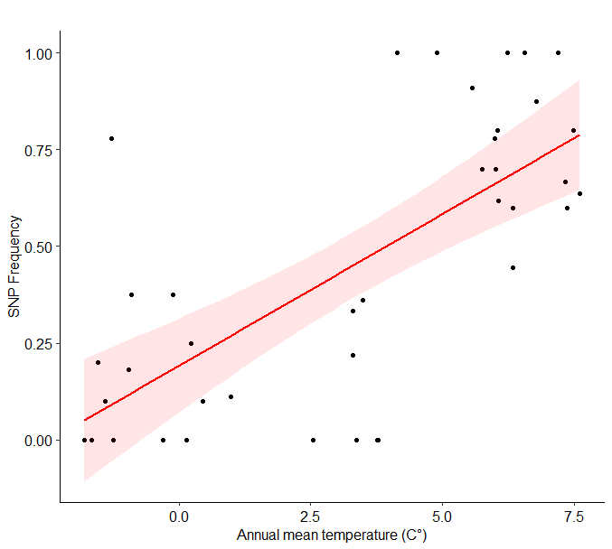

Wykonaj wykres korelacji **częstości alleli z mean_t** dla losowo wybranych alleli - z ramki **rand_allel_freq.**

**Zadanie 1**– Wykonaj wszystkie powyższe kroki, w raporcie zamieść wszystkie wymagane ryciny a także kod - w miejscu, które go wymaga. Porównaj rozkład częstości alleli dla loci oznaczonych jako PAV z losowo wybranymi loci. Czy zauważasz trend w geograficznym rozmieszczeniu loci outlierowych? Czy wszystkie loci wykazują ten sam trend? Jaki jest związek średniej temperatury z częstością alleli PAV? Czy ten związek występuje dla losowo wybranych SNP?

## Genomic vulnerability - prognozowane dane klimatyczne

Teraz musimy znaleźć zmienne środowiskowe dla przyszłości, jako pierwszy krok do modelowania zmian częstości alleli w przyszłości. Ponieważ nie da się dokładnie przewidzieć, jak będzie wyglądał klimat za kilkadziesiąt lat — głównie dlatego, że zależy to od tego, jak skutecznie ograniczymy emisje gazów cieplarnianych — przyjmuje się **różne scenariusze klimatyczne**. W badaniach tego typu często korzysta się z tzw. globalnych modeli cyrkulacji atmosferycznej (GCM). Dla uproszczenia w tym przypadku korzystamy tylko z jednego z nich — modelu **CNRM-CM6-1**, który jest częścią projektu CMIP6. To sprawdzony model, często używany w podobnych analizach.

Scenariusze klimatyczne, o których mówimy, nazywają się SSP (shared socio-economic pathways) albo RCP (representative concentration pathways). Pokazują one, jak może wyglądać klimat w zależności od tego, jak świat poradzi sobie z ograniczaniem emisji CO₂. Są różne warianty: od łagodnych (**RCP2.6**), przez umiarkowane (**RCP4.5**), aż po te najbardziej ekstremalne (**RCP8.5**). Więcej przeczytasz tu:  
https://www.ipcc-data.org/guidelines/pages/glossary/glossary_r.html

A tutaj zapoznasz się z raportem IPCC:

https://www.ipcc.ch/report/ar6/syr/downloads/report/IPCC_AR6_SYR_SPM.pdf

```r
# pobieramy wszystkie zmienne bioklimatyczne dla modelu RCP 2.6 i okresu 2041-2060

bio_26 <- cmip6_world(model = "CNRM-CM6-1",
                                       ssp = "126",
                                       time = "2041-2060",
                                       var = "bio",
                                       res = 2.5,
                                       version = "2.1",
                                       path = tempdir())

# analogicznie jak dla klimatu współczesnego - wyciągamy zmienne dla naszych populacji
# potrzebujemy obiektu sf z naszymi lokaliacjami

meta_pops_sf <- st_as_sf(meta_pops, coords = c("lon", "lat"), crs = 4326)

# wycinamy wartości dla tych współrzędnych z rastra
env_df_26 <- terra::extract(bio_26, meta_pops_sf)[, -1]
# w finalnej ramce pozbywamy się pierwszej kolumny

# wybieramy te same 4 zmienne środowiskowe jak w przypadku współczesnych danych środowiskowych

env_df_26 <- env_df_26[,c(X,X,X,X)]
colnames(env_df_26) <- XXX # ustawiamy takie same nazy zmiennych
```

Sprawdźmy jakiego zakresu zmian temperatury się spodziewamy i **czy wsystępują różnice w zakresie prognozowanych zmian dla naszych regionów**?

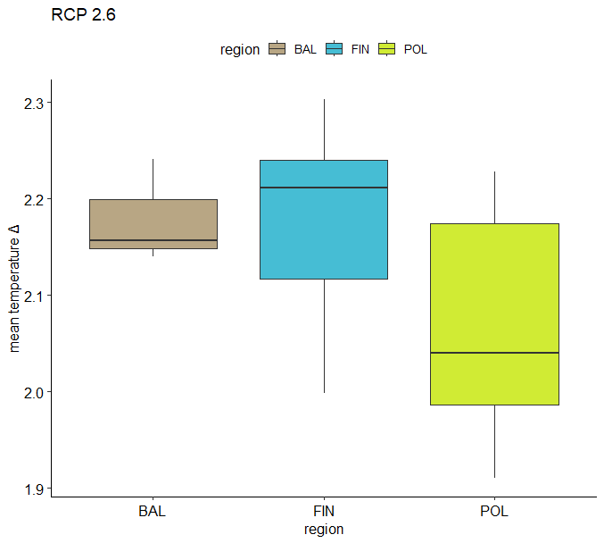

```r
# Stworzymy ramkę danych z obecną i przyszłą temperaturą - oraz populacją i regionem

df <- data.frame(
  pop = factor(meta_pops$pop, levels = meta_pops$pop),
  region = meta_pops$region,
  current_t = env_df$mean_t,
  future_t = env_df_26$mean_t
)


ggplot(df, aes(y = pop, col = region) ) +
    geom_segment(aes(x = current_t, xend = future_t, yend = pop),
               arrow = arrow(length = unit(0.2, "cm")), size = 1) +
  geom_point(aes(x = current_t), size = 2) +
  geom_point(aes(x = future_t), size = 2) +
  scale_color_manual(values = kolory)+
  theme_pubr()

## wykonaj boxplot porównujący średnią rożnicę temperatur (przyszły a obecny klimat) w badanych regionach.

## podaj kod użyty do tego zadania


XXX
```

**Zadanie 2** – Wykonaj wszystkie powyższe kroki, w raporcie zamieść wszystkie wymagane ryciny a także kod - w miejscu, które go wymaga.

## Genomic vulnerability - częstość alleli w przyszłości

Najprostszym sposobem uzyskania przewidywanej częstości alleli - zwłaszcza w naszym przypadku (RDA wykazało silny związek wyłącznie ze średnią temperaturą), byłoby regresja liniowa między danym SNP a zmienną środowiskową. Jendak poprawniej będzie wykorzystać model RDA który uwzględnia wielowymiarowe zależności pomiędzy zmiennymi. Skorzystamy z pakietu **AlleleShift**, używając funkcji `count.pred` oraz `freq.pred`, opartych na wcześniej skonstruowanym modelu RDA - identycznym z tym, który wykonaliśmy na poprzednich zajęciach. Otrzymamy zatem finalnie **częstość PAV dla zmiennych środowiskowych w modelu RCP 2.6**.

```r
### Alele shift

# jako plik wejścia wymagany jest obiekt genpop - który łatwo można utworzyć z genind w sdegenet

# najpier okroimy naszego genind tylko do loci PAV

genind_pav <- genind_pines[loc = PAV_df$SNP_name]
# konwersja na genpop
genpop_pav <-genind2genpop(genind_pav)



pines_count_model <- count.model(genpop.data =genpop_pav ,
                                  env.data=env_df,
                                  ordistep=F)


# W tym kroku następuje (za naszymi plecami - odtworzenie modelu RDA)
# zwracany obiekt (Pines_count_model)
# – Jest to obiekt klasy cca (z pakietu vegan), zawierający model analizy RDA, który odwzorowuje zależności między allelami a zmiennymi środowiskowymi.
# – Może być wykorzystany w kolejnych krokach pakietu AlleleShift, np. do przewidywania przyszłych liczebności (count.pred) i przeliczenia ich na częstości (freq.pred).


pines_pred_baseline <- count.pred(pines_count_model, env.data=env_df)
pines_freq_model <- freq.model(pines_pred_baseline)
pines_freq_baseline <- freq.pred(pines_freq_model,
                                  count.predicted=pines_pred_baseline)

# powyżej są dwa kroki, w których następuje dwukrokowa kalibracja modelu - predykcji częstości alleli - ostatecznie
# by mieć pewność że model poprawnie przewiduje przyszłą częstość alleli - program sprawdza jak dobrze potrafi "odgadnąć" częstości obecne
```

Nasz model dobrze przewiduje częstości alleli dla wszystkich populacji - o czym świadczą wysokie wartości R2

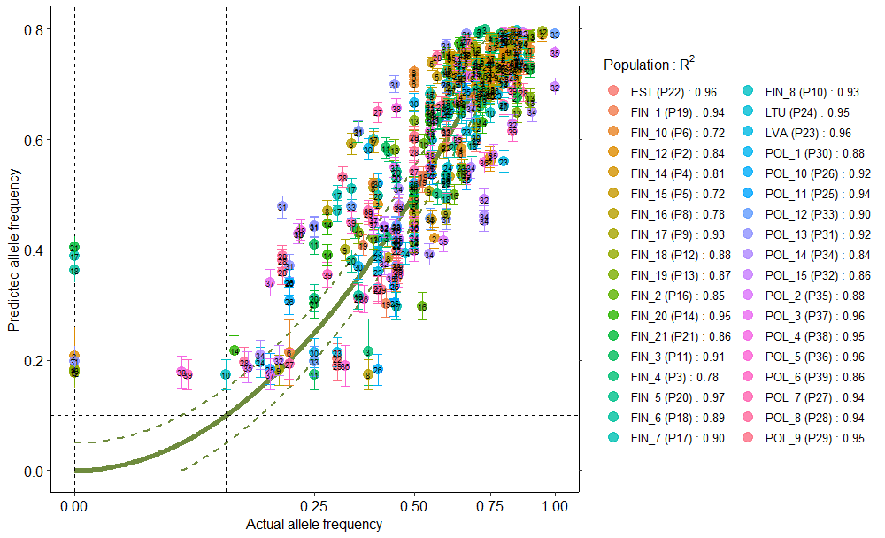

Po skalibrowaniu modelu - jesteśmy gotowi na **przewidywanie częstości aleli dla przyszłego klimatu**!

```r
# zauważ, że dla innych danych środowiskowych  - w pierwszym kroku zmieni się wyłącznie obiekt env.data - pines_count_model nie
pines_pred_future_26 <- count.pred(pines_count_model, env.data=env_df_26)
# pines_freq_model również jest niezmienny - count.predicted to obiekt uzyskany powyżej
pines_freq_future_26 <- freq.pred(pines_freq_model,
                                 count.predicted=pines_pred_future_26)

## interesujące nas kolumny to Allele.freq i Freq.e2
```

## Genomic vulnerability - oszacowanie i projekcja w zasięgu

Kolumny **Allele.freq** i **Freq.e2** zawierają odpowiednio częstość allelu dla **obcecnego klimatu i przyszłego klimatu**. Tych wartość użyjemy do oszacowanie **genomic vulnerability**.

Istnieją różne metody obliczania tej statystyki, ale użyjemy najprostszego i oryginalnego jej sformułowania: https://onlinelibrary.wiley.com/doi/10.1111/mec.13889 - **średnią zmianę** częstości alleli we wszystkich loci PAV (w tym przypadku 28 loci wybranych przez 3 różne metody). Wyciągnięcie tych danych wymaga manipulacji ramką **pines_freq_future_26** - najpierw obliczenia różnicy czestości alleli dla każdego SNP dla każdej populacji, a następnie średniej po populacjach - użyjemy customowej funkcji.

```r
## wczytaj funkcję do obliczenia gv
source("calc_gv.R")

gv_df_RCP26 <- calculate_genomic_vulnerability(
  freq_df = pines_freq_future_26,
  meta_df = meta_pops,
  pop_names = meta_pops$pop,
  model_name = "RCP26"
)

head(gv_df_RCP26)
```

Przygotujemy kilka wizualizacji naszego genomic vulnerability - **heatmap z wartościami gv**, **boxplot porównujący gv w regionach** oraz **interpolację wartości gv w badanym zasięgu**, na podstawie wartości dla populacji.

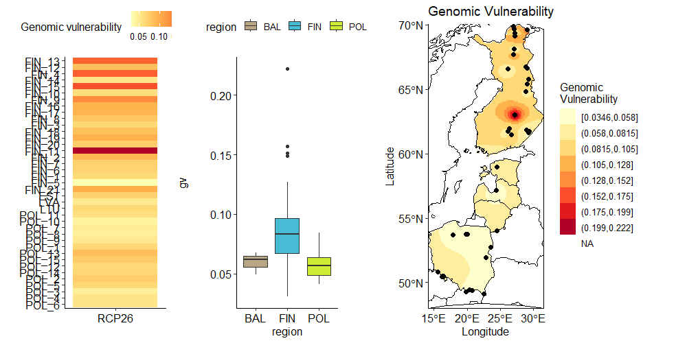

```r
gv_plot <- ggplot(gv_df_RCP26, aes(x = model, y = pops_order, fill = gv)) +
  geom_tile() +
  scale_fill_distiller(palette = "YlOrRd",direction = 1) +
  labs(fill = "Genomic vulnerability")+
  xlab(label = "")+
  ylab(label = "")
  theme_pubr()

gv_plot

gv_boxplot <- XXXX # zadanie dla Ciebie

# uzyjemy funkcji customowej
source("calc_gv.R")
gv_map <- plot_genomic_vulnerability(coords_sf = coords_sf,gv_values = gv_df_RCP26$gv,n_breaks = 8)
```

**Zadanie 3** – Oblicz genomic vulnerability dla populacji sosny w badanym zasięsięgu. Wykonaj wszystkie powyższe kroki, w raporcie zamieść wszystkie wymagane ryciny a także kod - w miejscu, które go wymaga. Zastanów się i odpowiedz, czy wzór genomic vulnerability jest zbieżny z różnicą temperatur między obecnym a przyszłym klimatem?

Powtórz analizy dla tych dwóch modeli. Odtwórz i zaraportuj:

1. boxplot porównujący **średnią rożnicę temperatur** (przyszły a obecny klimat) w badanych regionach.
2. Wspólny dla **3 scenariuszy** wykres heatmap dla genomic vilnerability.
3. Wykres gv na mapie.

**Zadanie 4** – Oblicz genomic vulnerability dla populacji sosny w badanym zasięsięgu. Wykonaj wszystkie powyższe kroki, w raporcie zamieść wszystkie wymagane ryciny a także kod - w miejscu, które go wymaga. Zastanów się i odpowiedz, czy wzór genomic vulnerability jest zbieżny z różnicą temperatur między obecnym a przyszłym klimatem?

## Zadanie końcowe - podsumowanie ćwiczeń

Napisz sprawozdanie, w którym podsumujesz podejście **genomic vulnerability (GV)** stosowane w genomice środowiskowej lub konserwatorskiej. Porusz takie zagadnienia jak:

1. **ograniczenia tej metody** – zarówno techniczne, jak i biologiczne. Rozważ m.in.:
   - Rozdzielczość i zagęszczenie markerów genetycznych (czy obejmują całe genomy, czy tylko ich fragmenty?)
   - Niepewność modelowania (np. projekcje klimatyczne, modele statystyczne jak RDA
   - Sposób liczenia gv - rozważ np. zmianę częstości allelu bliską utrwalenia - np dla populacji gdzie wynosi ona 0.9 - a maksymalna częstość to 1.
2. **alternatywne metody szacowania genomic vulnerability** - https://onlinelibrary.wiley.com/doi/full/10.1111/1755-0998.14008
3. **praktyczne zastosowanie gv w ochrony przyrody**